# The dynamic landscape of peptide function prediction

### Software information

| Name | DOI | Year | Citations | Reproducibility standard | Web server | Web server activity | Web server functionality | Model repository | Training repository | Antiangiogenic | Antibacterial | Antibiofilm | Anticancer | Antifungal | Antihypertensive | Antiinflammatory | Antimicrobial | Antiparasitic | Antiviral | Blood-brain barrier | Cell-penetrating | Chemotactic | Neuropeptides | Quorum sensing | Surface-binding | Toxic |
| --- | --- | --- | --- | --- | --- | --- | --- | --- | --- | --- | --- | --- | --- | --- | --- | --- | --- | --- | --- | --- | --- | --- | --- | --- | --- | --- |
| Deep-ABPpred | 10.1093/bib/bbab065 | 2021 | 16 | below bronze | Web server | True | False | false | false | False | True | False | False | False | False | False | False | False | False | False | False | False | False | False | False | False |
| StaBle-ABPpred | 10.1093/bib/bbab439 | 2021 | 3 | below bronze | Web server | True | False | false | false | False | True | False | False | False | False | False | False | False | False | False | False | False | False | False | False | False |
| ACP-DA | 10.3389/fgene.2021.698477 | 2021 | 4 | below bronze | false | False | False | Repository | false | False | False | False | True | False | False | False | False | False | False | False | False | False | False | False | False | False |
| ACP-DL | 10.1016/j.omtn.2019.04.025 | 2019 | 79 | bronze | false | False | False | Repository | Repository | False | False | False | True | False | False | False | False | False | False | False | False | False | False | False | False | False |
| ACP-MHCNN | 10.1038/s41598-021-02703-3 | 2021 | 5 | gold | Web server | True | True | Repository | Repository | False | False | False | True | False | False | False | False | False | False | False | False | False | False | False | False | False |
| ACPP | 10.1007/s10989-014-9435-7 | 2014 | 59 | below bronze | Web server | False | False | false | false | False | False | False | True | False | False | False | False | False | False | False | False | False | False | False | False | False |
| ACPred | 10.3390/molecules24101973 | 2019 | 84 | below bronze | Web server | True | True | false | false | False | False | False | True | False | False | False | False | False | False | False | False | False | False | False | False | False |
| ACPred-FL | 10.1093/bioinformatics/bty451 | 2018 | 122 | below bronze | Web server | True | False | false | false | False | False | False | True | False | False | False | False | False | False | False | False | False | False | False | False | False |
| ACPred-Fuse | 10.1093/bib/bbz088 | 2019 | 53 | below bronze | Web server | False | False | false | false | False | False | False | True | False | False | False | False | False | False | False | False | False | False | False | False | False |
| AMP0 | 10.1109/TCBB.2020.2999399 | 2022 | 3 | below bronze | Web server | True | True | false | false | False | False | False | False | False | False | False | True | False | False | False | False | False | False | False | False | False |

[output cut: 130 more lines]

### Data collection & curation

To collect software for the prediction of peptide activities, we searched PubMed and Google Scholar databases using queries such as “antimicrobial peptide prediction”, “anticancer peptide prediction”, etc. We focused on the search results that described software or reviewed/compared available tools for the prediction of a given activity.

Eligibility criteria:

- the tool needs to be published in a peer-review journal until 1st July 2022.
- we include models that are superceded by their next version.

We manually curated all information for software featured in a ‘Software information’ tab. To do that we carefully analysed publications describing given software looking for the following information:

- peptide activities predicted by a model,
- link to the web server (**Web server** column),
- link to the model, i.e. a repository with a trained model which can be used for prediction or an address of the model implemented as standalone software (**Model repository** column),
- link to the repository with all the code and data necessary to train/retrain the model (**Training repository** column).

Then, we checked if the links to the web servers provided in the articles were still working and if they function correctly, i.e. provide understandable output after running prediction. This information is indicated in the **Web server activity** and **Web server functionality** columns, respectively.

The availability of web servers was assessed on October 14th, 2022. The year of publication and the number of citations were obtained from CrossRef on October 14th, 2022.

We also inspected available code to determine the reproducibility standard (adapted from [Heil et al.](https://doi.org/10.1038/s41592-021-01256-7) and indicated in the **Reproducibility standard** column). We are additionally using the category *below bronze*, when a model does not fulfill criteria even for the bronze category.

### About and citation

This website accompanies our publication: *The dynamic landscape of peptide function prediction*.

**Citation**: Oriol Bárcenas, Carlos Pintado-Grima, Katarzyna Sidorczuk, Felix Teufel, Henrik Nielsen, Salvador Ventura and Michał Burdukiewicz, *The dynamic landscape of peptide function prediction*, Computational and Structural Biotechnology Journal, 10.1016/j.csbj.2022.11.043.

### Authors

#### Oriol Bárcenas

[figure not shown]

Oriol Bárcenas is an undergraduate bioinformatics researcher at the Institute of Biotechnology and Biomedicine at the Autonomous University of Barcelona (UAB). He is a Biotechnology B.Sc. graduate from UAB (2022) and has joined a Mathematical Modelling and Data Science M.Sc. He will follow his career by enrolling in the joint Bioinformatics Ph.D. program at UAB. His research will focus on the analysis of protein folding and aggregation data, as well as in silico protein design.

Twitter: https://twitter.com/oriolbarcenas

#### Michał Burdukiewicz

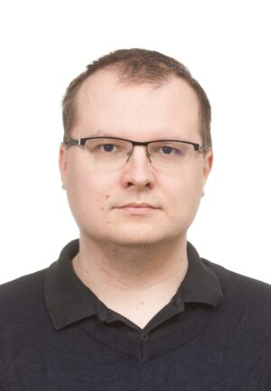

Michał Burdukiewicz is currently working as a post-doc at the Institute of Biotechnology and Biomedicine at the Autonomous University of Barcelona and a research assistant in the Centre for Clinical Research at the Medical University of Białystok. His research interests cover machine learning applications in the functional analysis of peptides and proteins, focusing on amyloids. Moreover, he is co-developing tools for proteomics, mainly hydrogen-deuterium exchange monitored by mass spectrometry.

Contact: michalburdukiewicz[at]gmail.com

Twitter: https://twitter.com/burdukiewicz

Website: https://github.com/michbur

#### Henrik Nielsen

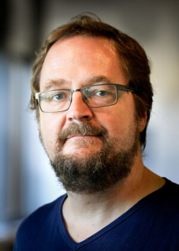

Henrik Nielsen is PhD in Biochemistry and an associate professor at the Technical University of Denmark. His research uses machine learning to predict the subcellular localization of proteins. Henrik’s findings are available through his tools, such as SignalP or [TargetP](https://services.healthtech.dtu.dk/service.php?TargetP-2.0) or [DeepLoc](https://services.healthtech.dtu.dk/service.php?DeepLoc-2.0).

Website: https://www.healthtech.dtu.dk/protein-sorting

#### Carlos Pintado-Grima

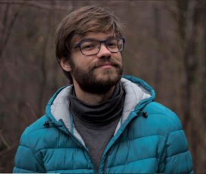

Carlos Pintado-Grima is a PhD student in Bioinformatics at the Institute of Biotechnology and Biomedicine at the Autonomous University of Barcelona (UAB). He obtained his degree in Biology and the Bachelor of Science at UAB and Thompson Rivers University (Kamloops, BC, Canada). He recieved his M.Sc. in Bioinformatics in 2020 at UAB. His current research is focused on the development and analysis of bioinformatics tools to better understand protein aggregation, folding and misfolding.

Twitter: https://twitter.com/cpintadogrima

#### Katarzyna Sidorczuk

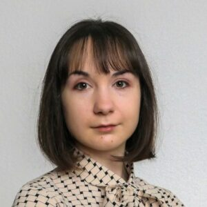

Katarzyna Sidorczuk received the M.Sc. degree in biotechnology from the University of Wrocław, Poland, in 2019. She is currently pursuing the Ph.D. degree in biological sciences at the University of Wrocław. Her research focuses on bioinformatics and machine learning approaches for the analysis and prediction of peptide functions, protein targeting sequences and bacterial adhesins.

Twitter: https://twitter.com/k_sidorczuk

#### Felix Teufel

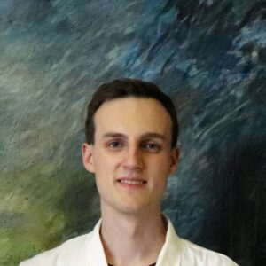

Felix Teufel is a PhD student in Machine Learning at the University of Copenhagen. He obtained his MSc in Biotechnology from ETH Zürich in 2021. His current research interests are understanding peptide function using structural methods, representation learning in biology and protein localization prediction.

Website: https://fteufel.github.io/

#### Salvador Ventura

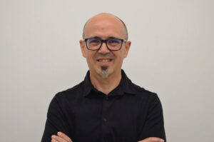

Salvador Ventura is a PhD in Biology and professor of Biochemistry and Molecular Biology at the Autonomous University of Barcelona (UAB). He is an ICREA researcher at the Institute of Biotechnology and Biomedicine (IBB) of the UAB, where he was also director, and leads a research group that investigates the link between protein structure and degenerative diseases to create new molecules to treat them.

Twitter: https://twitter.com/PPMC_UAB

Website: https://ibb.uab.cat/wp-content/themes/viral/modules/ibb_membres/view_grup.php?CodiGrup=36